# Introduction to `MatchingPursuit` package

authors: Artur Gramacki & Jarosław Gramacki

## 1 R version and generation time

```
## R version:    4.5.1
## Generated on: 18-March-2026
```

## 2 Installation

```r
# Install and load required R packages
pkgs <- c(
  "edf", "signal", "RSQLite", "DescTools", "imager", "raster", "graphics", "grDevices",
  "utils", "knitr", "rmarkdown", "latex2exp", "knitr", "rmarkdown", "remotes",  "digest")

to_install = !pkgs %in% installed.packages()

if(any(to_install)) {
  install.packages(pkgs[to_install], repos = "http://cran.us.r-project.org")
}

library(MatchingPursuit)
```

## 3 The purpose of the package

The presented package allows you to analyse any time-series signals using the Matching Pursuit (MP) algorithm (see Mallat and Zhang (1993), Tropp and Gilbert (2008)). Additionally, you can work with EEG electroencephalogram signals by:

1. Loading files in EDF and EDF+ formats
2. Performing 3 typical EEG montages
3. Pre-filtering the signals

Back to menu

## 4 Quick start

Let’s generate an example mixing of seven different non-stationary signals. The resulting signal (highlighted in blue below) will be used to demonstrate the basic functionality of the package.

### Step 1

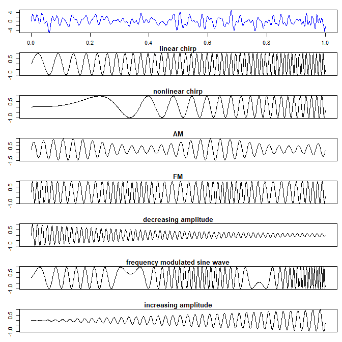

Data must my stored in data frame: rows = samples for all channels, columns = channels. Our first demo dataset consists of only one channel (one column). The `read.csv.signals()` function checks if the data has correct structure. The first line of the file must contain two numbers: the sampling rate in Hz () and the signal length in seconds () This checks whether the file actually contains samples.

```r
file <- system.file("extdata", "sample1.csv", package = "MatchingPursuit")

signal <- read.csv.signals(file)

class(signal)
## [1] "data.frame"

head(signal)
##         v1
## 1 0.000000
## 2 1.024921
## 3 1.937564
## 4 2.638751
## 5 3.059493
## 6 3.170315
```

Back to menu

### Step 2

The input data (`signal`) is passed as an input parameter to the `empi.execute()` function which generates a file in `SQLite` format (`empi.db`) that stores all atom parameters. This `.db` file is stored in a temporary directory created by `tempfile()` function.

The function first downloads (if it hasn’t been downloaded before) and then runs an external program from the internet. This program is a very fast and efficient implementation of the Matching Pursuit algorithm. The author calls it **Enhanced Matching Pursuit Implementation**, or **empi** for short, see Różański (2024) for details. The download link and name of the downloaded resource are displayed below (if running in Linux and macOS systems, appropriate binary versions are downloaded).

```r
locate.empi()
## $url
## [1] "https://drive.google.com/uc?export=download&id=1L1ZEBMW0dcb1-jCC3kur8VceijWogCJm"
##
## $fname
## [1] "empi-1.0.3-windows-x64.zip"
```

**Important note:** The code in the below chunk has been commented out because CRAN’s code verification rules prevent automatic binary downloads. Therefore, this function should not be run here. However, when this function is run by the user in interactive mode (if the `interactive()` function returns `TRUE`), the user is asked if they agree to download the external binary. If they agree, the required files are downloaded and saved in the current directory.

Due to CRAN limitations (discussed above), this file was generated by the authors and stored in the package (`sample1.db`) . In the next chunk, the `empi2ft()` function uses this file as input (the `db.file` parameter).

Notice the `empi.options` parameter in the `empi.execute()` function. You can specify the value `NULL` there, and *empi* program will run with the default values set in the function (`"-o local --gabor -i 50"`). It is also worth noting that it has a wide range of configuration options. Details can be found in the `README.md` (in the directory where the *empi* program was saved) file. In our example, parameters were entered that tell the program to find 25 atoms.

```r
# empi.download()

# empi.out <- empi.execute (
#   signal = signal,
#   sampling.rate = 1024,
#   empi.options = "-o local --gabor -i 25",
#   write.to.file = TRUE
# )
```

Back to menu

### Step 3

Generating the final time-frequency map (T-F) for the selected channel. The centres of atoms (in the sense of time and frequency coordinates) are marked with the numbers of subsequent atoms, sorted from the highest to the lowest energy.

Comparing the two signal waveforms under the T-F map, it can be seen that the original signal and the one after reconstruction differ only minimally.

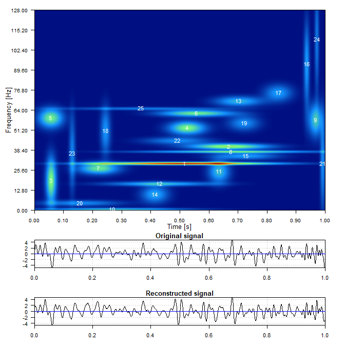

```
## Channel: 1
## Number of atoms: 25
## Sampling rate: 1024
## Epoch size (in points): 1024
## Signal length (in seconds): 1
##
## Energy of the original signal:      2746.16
## Signal energy after reconstruction: 2582.88
## reconstruction / original %:        94.05424
```

```r
# Reading a SQLite file where all the generated atom's parameters are stored.
file <- system.file("extdata", "sample1.db", package = "MatchingPursuit")

# Create time-frequency map based on MP atoms.
out <- empi2tf(
  db.file = file,
  channel = 1,
  mode = "sqrt",
  freq.divide = 4,
  increase.factor= 4,
  display.crosses = FALSE,
  display.atom.numbers = TRUE,
  out.mode = "plot"
)
```

Below the plot, basic signal parameters are displayed, along with information about the number of atoms into which the input signal was decomposed.

Furthermore, the energy of the input signal and the signal reconstructed from the atoms are also calculated. The obtained result shows that more of the energy of the original signal was “explained” by the generated atoms (94.05%). Of course, the number of generated atoms can be increased, then the energy of the reconstructed signal will most likely be closer to 100%.

Back to menu

## 5 Electroencephalogram (EEG) analysis

In this section, we demonstrate how to analyze electroencephalography (EEG) signals using the Matching Pursuit algorithm. The package includes a dedicated function for reading files saved in EDF and EDF+ formats (European Data Format). You can also perform three different types of montages as well as filtering the signals.

### Step 1

```r
file <- system.file("extdata", "EEG.edf", package = "MatchingPursuit")

# Extract signals from EDF file.
signal <- read.edf.signals(file, resampling = FALSE, from = 0, to = 10)

# Read signal main parameters.
pars <- read.edf.params(file)
sampling.rate <- pars$frequency[1]

# Read signal parameters and display them in a tabular form.
read.edf.params(file)
##       channel.name frequency no.of.samples length.sec
## 1              Fp1       256          2560         10
## 2              Fp2       256          2560         10
## 3               F3       256          2560         10
## 4               F4       256          2560         10
## 5               F7       256          2560         10
## 6               F8       256          2560         10
## 7               Fz       256          2560         10
## 8               C3       256          2560         10
## 9               C4       256          2560         10
## 10              Cz       256          2560         10
## 11              T3       256          2560         10
## 12              T5       256          2560         10
## 13              T4       256          2560         10
## 14              T6       256          2560         10
## 15              P3       256          2560         10
## 16              P4       256          2560         10
## 17              Pz       256          2560         10
## 18              O1       256          2560         10
## 19              O2       256          2560         10
## 20 EDF_Annotations        57           627         11
```

Back to menu

### Step 2 (sometimes required)

Sometimes it is necessary to change the sampling frequency (increase – *upsampling* or decrease – *downsampling*). The `read.edf.signals()` function implements this functionality. In the example below the original sampling frequency is reduced from 256 Hz to 64 Hz.

```r
file <- system.file("extdata", "EEG.edf", package = "MatchingPursuit")

# Original signal
signal <- read.edf.signals(file, resampling = FALSE, from = 0, to = 10)

# Resampled signal
signal.resampled <- read.edf.signals(file, resampling = TRUE, f.new = 64,  from = 0, to = 10)
```

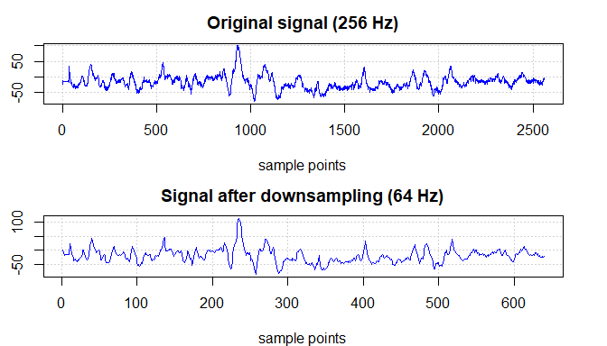

Back to menu

### Step 3 (usually required)

A bipolar montage is created (the classical *double banana* montage). Each channel compares two adjacent electrodes. In the first step, you define the pairs of electrodes to be connected (`pairs` list). In the second step function `eeg.montage()` generates the required montage.

```r
# Pairs of signals for bipolar montage (so called "double banana").
pairs <- list(
  c("Fp2", "F4"), c("F4",  "C4"), c("C4",  "P4"), c("P4",  "O2"), c("Fp1", "F3"), c("F3",  "C3"),
  c("C3",  "P3"), c("P3",  "O1"), c("Fp2", "F8"), c("F8",  "T4"), c("T4",  "T6"), c("T6",  "O2"),
  c("Fp1", "F7"), c("F7",  "T3"), c("T3",  "T5"), c("T5",  "O1"), c("Fz",  "Cz"), c("Cz",  "Pz")
)

# Make the bipolar montage.
bip.montage <- eeg.montage(signal, montage.type = c("bipolar"), bipolar.pairs = pairs)

# Original signal.
head(signal[, 1:7])
##         Fp1       Fp2        F3        F4         F7        F8        Fz
## 1 -22.71201 -25.55728 -23.71532 -24.88713 -20.368393 -24.38547 -22.88050
## 2 -12.67505 -18.02861 -14.51318 -16.68830  -7.823155 -16.02198 -12.83972
## 3 -15.18333 -19.86674 -16.68830 -18.69876 -10.833093 -18.02861 -15.18333
## 4 -13.84686 -18.86342 -15.51650 -17.52695  -9.328124 -17.02529 -14.01153
## 5 -14.51318 -19.53358 -16.18665 -18.19710 -10.162942 -17.69162 -14.68168
## 6 -14.01153 -19.20041 -15.85349 -17.86011  -9.661285 -17.18996 -14.18002

# Signal after banana montage.
head(bip.montage[, 1:7])
##       Fp2_F4      F4_C4     C4_P4     P4_O2   Fp1_F3     F3_C3      C3_P3
## 1 -0.6701516 -0.1684953 -1.167979 0.3331611 1.003313 -1.003313 -0.3331611
## 2 -1.3403032 -0.3331611 -2.006625 0.6663222 1.838130 -2.006625 -0.6701516
## 3 -1.1679785 -0.3369905 -1.838130 0.5016563 1.504969 -1.673464 -0.6663222
## 4 -1.3364738 -0.3369905 -1.838130 0.6701516 1.669635 -1.838130 -0.6701516
## 5 -1.3364738 -0.1684953 -2.006625 0.5016563 1.673464 -1.673464 -0.6663222
## 6 -1.3403032 -0.3331611 -2.010455 0.5054858 1.841960 -1.841960 -0.8348174
```

Back to menu

### Step 4 (usually required)

EEG signals are rarely analysed without first being filtered. Using the `filters.coeff()` function, you define filter parameters and then filter the signal. The filter parameters given below have typical values recommended in the literature.

```r
# Filter parameters that will be used (quite typical in filtering EEG signals).
fc <- filters.coeff(
   fs = sampling.rate,
   notch = c(49, 51),
   lowpass = 40,
   highpass = 1,
)

# Filtering input signals.
bip.montage.filt <- bip.montage

for (m in 1:ncol(bip.montage)) {
  bip.montage.filt[, m] = signal::filtfilt(fc$notch, bip.montage[, m])     # 50Hz notch filter
  bip.montage.filt[, m] = signal::filtfilt(fc$low, bip.montage.filt[, m])  # Low pass IIR Butterworth
  bip.montage.filt[, m] = signal::filtfilt(fc$high, bip.montage.filt[, m]) # High pass IIR Butterwoth
}
```

For the selected channel (after bipolar montage it is named Fp2_F4), the original and filtered signals are displayed. Clearly, the filtering effect is positive.

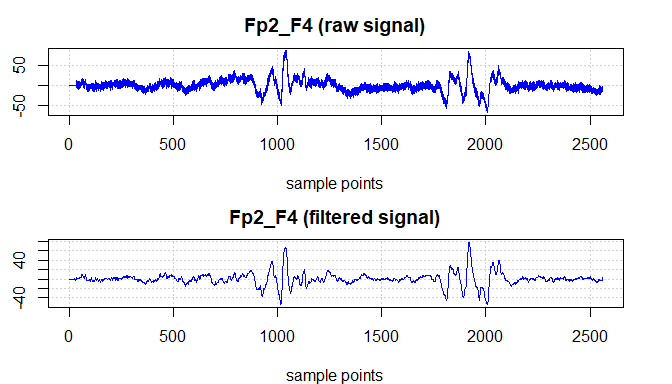

Back to menu

### Step 5

**Important note:** The code below has been commented out. See the explanation given here.

```r
# empi.download()

# The empi.options parameter is NULL, so the empi program is
# run with the parameters "-o local --gabor -i 50"
# empi.out <- empi.execute (
#   signal = signal,
#   sampling.rate = 1024,
#   empi.options = NULL,
#   write.to.file = TRUE
# )
```

Generating the final time-frequency map for the selected channel (Fp2_F4). The canters of atoms (in the sense of time and frequency coordinates) are marked with white crosses.

Comparing the two signal twaveforms under the T-F map, it can be seen that the original signal and the one after reconstruction differ only minimally.

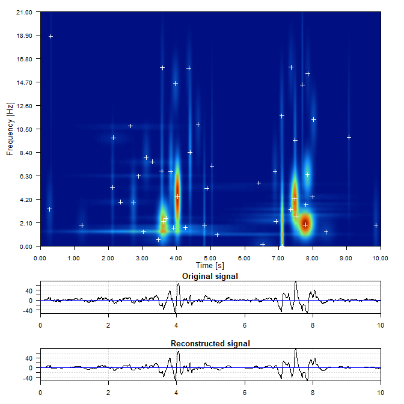

```
## Channel: 1
## Number of atoms: 50
## Sampling rate: 256
## Epoch size (in points): 2560
## Signal length (in seconds): 10
##
## Energy of the original signal:      499028.1
## Signal energy after reconstruction: 487807.1
## reconstruction / original %:        97.75143
```

```r
# Reading a SQLite file where all the generated atom's parameters are stored.
file <- system.file("extdata", "EEG_bipolar_filtered.db", package = "MatchingPursuit")

# Generate time-frequency map based on MP atoms.
out <- empi2tf(
  db.file = file,
  channel = 1,
  mode = "sqrt",
  freq.divide = 6,
  increase.factor= 4,
  display.crosses = TRUE,
  display.atom.numbers = FALSE,
  out.mode = "plot"
)
```

Below the plot, basic signal parameters are displayed, along with information about the number of atoms into which the input signal was decomposed.

Furthermore, the energy of the input signal and the signal reconstructed from the generated atoms are also calculated. The obtained result shows that almost all of the energy of the original signal was “explained” by the generated atoms (97.75%).

Back to menu

## 6 Selected auxilary functions

### `atom.params()`

```r
file <- system.file("extdata", "sample1.db", package = "MatchingPursuit")
(ap <- atom.params(file))
##    channel_id atom_number amplitude energy frequency  phase scale position
## 1           1           1     1.396  0.560    30.129  1.032 0.812    0.515
## 2           1           2     1.187  0.188    41.009 -2.675 0.378    0.668
## 3           1           3     3.051  0.162    19.161  2.909 0.049    0.056
## 4           1           4     1.612  0.158    52.881  0.835 0.173    0.525
## 5           1           5     1.859  0.143    59.245  0.580 0.117    0.055
## 6           1           6     1.063  0.139    62.278  2.493 0.349    0.557
## 7           1           7     1.367  0.128    27.042  0.227 0.194    0.220
## 8           1           8     0.590  0.107    37.685  2.694 0.872    0.676
## 9           1           9     1.903  0.088    58.038 -1.588 0.069    0.967
## 10          1          10     0.541  0.084     0.717  0.510 0.742    0.268
## 11          1          11     1.461  0.075    24.971 -0.558 0.100    0.635
## 12          1          12     0.614  0.067    17.111  0.696 0.506    0.430
## 13          1          13     0.917  0.066    69.964  3.105 0.223    0.702
## 14          1          14     1.108  0.057    10.347  1.641 0.131    0.414
## 15          1          15     0.668  0.049    34.951 -2.350 0.307    0.725
## 16          1          16     2.238  0.048    93.506  1.292 0.027    0.937
## 17          1          17     1.001  0.048    75.322  1.867 0.134    0.839
## 18          1          18     1.573  0.042    51.072  1.628 0.048    0.244
## 19          1          19     0.862  0.039    55.968  1.787 0.150    0.721
## 20          1          20     0.521  0.036     4.740 -1.830 0.380    0.156
## 21          1          21     2.066  0.036    30.172  2.292 0.024    0.992
## 22          1          22     0.549  0.034    44.676  1.637 0.317    0.491
## 23          1          23     1.708  0.031    36.527 -1.958 0.030    0.129
## 24          1          24     1.886  0.026   109.382  1.142 0.021    0.972
## 25          1          25     0.319  0.026    65.308 -2.085 0.733    0.366
```

**Important:** It should be clearly emphasized that in general, the number of atoms generated for each channel need not be the same. However, in our example, we have a special situation where the number of atoms in each channel is exactly the same.

```r
file <- system.file("extdata", "EEG_bipolar_filtered.db", package = "MatchingPursuit")
ap <- atom.params(file)
head(ap, 6)
##   channel_id atom_number amplitude  energy frequency  phase scale position
## 1          1           1    45.703 464.841     1.910 -2.885 0.629    7.783
## 2          1           2    72.222 450.535     4.457 -0.791 0.244    4.023
## 3          1           3    48.706 273.616     4.250 -0.913 0.326    7.470
## 4          1           4 16400.149 200.846     0.012 -1.571 0.132    7.101
## 5          1           5    33.193 169.123     2.224 -2.751 0.433    3.616
## 6          1           6    23.756  76.979     6.406 -2.762 0.386    7.844
tail(ap, 6)
##     channel_id atom_number amplitude energy frequency  phase scale position
## 895         18          45     9.054  2.589    10.719 -0.480 0.089    9.945
## 896         18          46    13.936  2.506     4.878  1.501 0.070    0.237
## 897         18          47     1.961  2.352     5.405  0.713 1.730    8.763
## 898         18          48     2.790  2.332     5.247  2.728 0.847    2.956
## 899         18          49     3.134  2.028    14.356 -1.172 0.584    4.155
## 900         18          50     7.788  1.918     8.337  0.351 0.087    6.058
```

### `sig2bin()`

The `sig2bin()` function can be used to write input data to a binary file. This function is is used internally in the `empi.execute()` function. The binary data are floating-point values in the byte order of the current machine (no byte-order conversion is performed). For multichannel signals, first come the samples for all channels at `t = 0`, then for all channels at `t = Δt`, and so forth. In other words, the signal should be written in column-major order (rows = channels, columns = samples).

**Note:** The user does not work directly with `.bin` files. Binary files are used only in the `empi.execute()` function. The external **empi** program executed inside this function requires binary data as input. Moreover, the ability to convert text files to binary form may be useful if someone wants to work with **empi** independently of the R environment.

```r
file <- system.file("extdata", "sample1.csv", package = "MatchingPursuit")
signal <- read.csv.signals(file)
signal.bin <- sig2bin(data = signal, write.to.file = FALSE)
class(signal.bin)
## [1] "raw"

# First 4 elements of the signal.
head(signal, 4)
##         v1
## 1 0.000000
## 2 1.024921
## 3 1.937564
## 4 2.638751

# The same first 4 elements of the signal in binary (float, 4 bytes).
head(signal.bin, 16)
##  [1] 00 00 00 00 9b 30 83 3f 1b 02 f8 3f 4c e1 28 40
```

### `read.empi.db.file()`

Data from the generated `SQLite` file can be easily read using the `read.empi.db.file()` function. Below, data from a sample `.db` file is read. Original and the reconstructed signals are then extracted and displayed. The two signals are virtually indistinguishable from each other. This means that atoms are very good at reconstructing the analysed signal.

```r
file <- system.file("extdata", "sample1.db", package = "MatchingPursuit")
out <- read.empi.db.file(file)
```

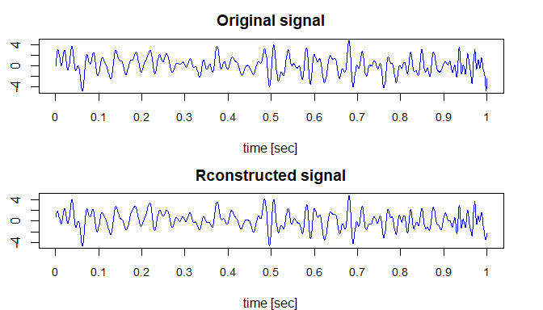

Back to menu

## 7 The Matching Pursuit algorithm in a nutshell

The Matching Pursuit algorithm is well-known and described in the literature Its purpose is to approximate the analyzed signal using so-called atoms. (the text below is adopted from Kunik and Gramacki (2025)).

Given a signal $f \in \mathbb{R}^n$, and a (possibly overcomplete) large redundant dictionary $D =\{g_{\gamma}\}_{\gamma \in \Gamma}$ of normalized atoms $\|g_{\gamma}\|=1$ MP finds a sparse signal representation

Each atom $g_{\gamma}$ is typically a time-frequency shifted and scaled version of a prototype function, such as the Gabor function (often called a Gaussian-windowed sinusoid). The dictionary is constructed to span a wide range of time and frequency characteristics. Real-valued Gabor function has the following form

$$g_{\gamma}(t) =
K(\gamma) e^{- \pi \left( \frac{t-\mu}{\sigma} \right) ^2}
\cos(\omega (t - \mu) + \phi)$$

where $\gamma = (\mu, \omega, \sigma, \phi)$ constitute a four-dimmensional space and $K(\gamma)$ is such that $||g_{\gamma}|| = 1$. It is easy to see that Gabor functions are constructed by multiplying Gaussian envelopes with cosine oscillations of different frequencies $\omega$ and phases offset $\phi$. By multiplying these two functions, we can obtain a wide variety of shapes depending on their parameters. A few examples of Gabor function are presented in figure below (in blue). The sinusoidal plane wave (in gray) is modulated by a Gaussian envelope (in red).

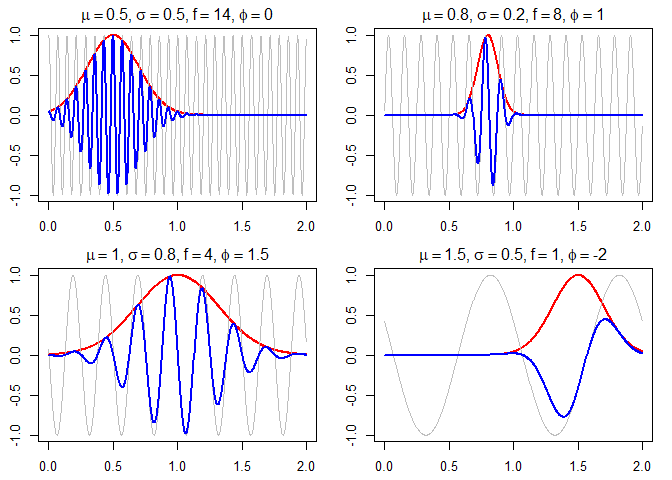

In the MP algorithm, the decomposition process is iterative. At each step, the algorithm selects an atom $g_{\gamma_n}$ from the dictionary $D$ that best matches the current residual signal $R$. Formally, starting with the signal $f$ at iteration $n=0$ the initial residual and initial function approximation are

$$R^0 = f \\
f^0 = 0$$

For each iteration $n = \{0,1,\ldots, N\}$ we find $g_{\gamma_n} \in D$ such that the following inner product $\langle \cdot, \cdot \rangle$ is maximized

$$g_{\gamma_n} = \arg \max_{\gamma \in \Gamma} | \langle R^{n}, g_{\gamma}
\rangle |$$

$$a_n = \langle R^{n}, g_{\gamma_n} \rangle$$

and updated function approximation is defined as

$$f^{n+1} = f^{n} + a_n g_{\gamma_n}$$
Similarly, updated residual is defined as

$$R^{n+1} = R^{n} - a_n g_{\gamma_n}$$
After $N$ iterations, the signal $f$ is approximated as

$$f \approx \sum_{n = 0}^{N} \langle R^n, g_{\gamma_n} \rangle
g_{\gamma_n} = \sum_{n = 0}^{N} a_n g_{\gamma_n}$$

or equivalently

$$f = \sum_{n = 0}^{N} \langle R^n g_{\gamma_n} \rangle g_{\gamma_n} +
R^{N+1}$$

The procedure stops when $\|R^{n+1}\|$ is below a threshold or after a fixed number of iterations.

$$||f||^2 = \sum_{n = 0}^{N} |\langle R^n, g_{\gamma_n} \rangle |^2 +
||R^{N+1}||^2$$
Back to menu

## Bibliogaphy

Kunik, M., and A. Gramacki. 2025. “Deep Learning Epileptic Seizure Detection based on the Matching Pursuit Algorithm and its Time–Frequency Graphical Representation.” *International Journal of Applied Mathematics and Computer Science* 35 (4): 617–30. https://doi.org/10.61822/amcs-2025-0044.

Mallat, S., and Z. Zhang. 1993. “Matching pursuits with time-frequency dictionaries.” *IEEE Transactions on Signal Processing* 41 (12): 3397–3415. https://doi.org/10.1109/78.258082.

Różański, P. T. 2024. “empi: GPU-Accelerated Matching Pursuit with Continuous Dictionaries.” *ACM Transactions on Mathematical Software* 50 (3): 1–17. https://doi.org/10.1145/3674832.

Tropp, J. A., and A. C. Gilbert. 2008. “Signal Recovery From Random Measurements Via Orthogonal Matching Pursuit.” *IEEE Transactions on Information Theory* 54 (12): 4655–66. https://doi.org/10.1109/TIT.2007.909108.